# Portfolio Assignment 2

Nadia Hajighassem

2024-11-13

```r
# install packages
pacman::p_load("dslabs",
               "tidyverse",
               "dplyr",
               "car",
               "hrbrthemes")
```

## Part 1

- Load the ’divorce_margarine’dataset from the ’dslabs’package. Investigate the correlation between margarine consumption and divorce rates in Maine. Would an increase in the preference for margarine lead to skyrocketing divorce rates?

```r
# loading in the data
df <- dslabs::divorce_margarine
```

```r
# lets take a look at the data
head(df)
```

```
##   divorce_rate_maine margarine_consumption_per_capita year
## 1                5.0                              8.2 2000
## 2                4.7                              7.0 2001
## 3                4.6                              6.5 2002
## 4                4.4                              5.3 2003
## 5                4.3                              5.2 2004
## 6                4.1                              4.0 2005
```

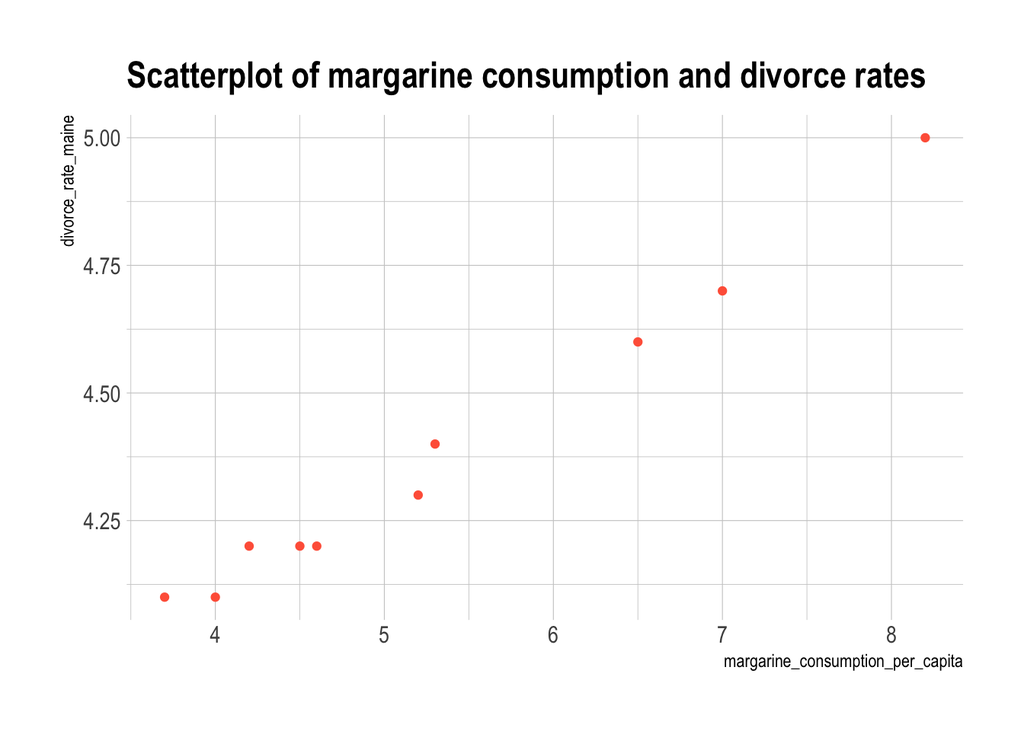

```r
# lets visualize it
df %>%
  ggplot(aes(x = margarine_consumption_per_capita, y = divorce_rate_maine)) +
    geom_point(color = "tomato") +
  theme_ipsum() +
  ggtitle("Scatterplot of margarine consumption and divorce rates")
```

```r
# correlation test
cor.test(df$margarine_consumption_per_capita, df$divorce_rate_maine)
```

```
##
##  Pearson's product-moment correlation
##
## data:  df$margarine_consumption_per_capita and df$divorce_rate_maine
## t = 23.055, df = 8, p-value = 1.33e-08
## alternative hypothesis: true correlation is not equal to 0
## 95 percent confidence interval:
##  0.9676666 0.9983038
## sample estimates:
##       cor
## 0.9925585
```

```r
# linear model
summary(lm(divorce_rate_maine ~ margarine_consumption_per_capita, df))
```

```
##
## Call:
## lm(formula = divorce_rate_maine ~ margarine_consumption_per_capita,
##     data = df)
##
## Residuals:
##      Min       1Q   Median       3Q      Max
## -0.05583 -0.01816 -0.01452  0.03601  0.04625
##
## Coefficients:
##                                  Estimate Std. Error t value Pr(>|t|)
## (Intercept)                      3.308626   0.048032   68.88 2.20e-12 ***
## margarine_consumption_per_capita 0.201386   0.008735   23.05 1.33e-08 ***
## ---
## Signif. codes:  0 '***' 0.001 '**' 0.01 '*' 0.05 '.' 0.1 ' ' 1
##
## Residual standard error: 0.03841 on 8 degrees of freedom
## Multiple R-squared:  0.9852, Adjusted R-squared:  0.9833
## F-statistic: 531.5 on 1 and 8 DF,  p-value: 1.33e-08
```

*Answer:*

The Pearson’s correlation coefficient is significant, r = 0.99, p = 1.33e-08. In fact, there is almost a perfect positive correlation between divorce rates and margarine consumption.

A linear regression model of this relationship was also created, where it can be assessed that Margarine consumption per capita is a significant predictor of divorce rate, b =0.20, p = 1.33e-08. Additionally, the \( R^2 \) value of 0.99 indicates that margarine consumption accounts for nearly all of the variance in divorce rates.

Although there seems to be a strong correlation between margarine consumption and divorce rates its important to mention that correlation is not equal to causation. Thus, this data does not suggest that margarine consumption results in divorce. Rather, the relationship may be a spurious association.

## Part 2

1. Load the ’GSSvocab’dataset from the ’car’package. This dataset contains people’s scores on an English vocabulary test and includes demographic information.

```r
# load in data
df_car <- carData::GSSvocab

# check out the data
head(df_car)
```

```
##        year gender nativeBorn ageGroup educGroup vocab age educ
## 1978.1 1978 female        yes    50-59    12 yrs    10  52   12
## 1978.2 1978 female        yes      60+   <12 yrs     6  74    9
## 1978.3 1978   male        yes    30-39   <12 yrs     4  35   10
## 1978.4 1978 female        yes    50-59    12 yrs     9  50   12
## 1978.5 1978 female        yes    40-49    12 yrs     6  41   12
## 1978.6 1978   male        yes    18-29    12 yrs     6  19   12
```

2.

Filter for the year 1978 and remove rows with missing values (the function na.exclude()is one way to do this–check out the documentation!).

```r
# filter for the year 1978
df_new <- filter(df_car, year == 1978 )

# remove NA
df_new <- na.exclude(df_new)

# sanity check
colSums(is.na(df_new))
```

```
##       year     gender nativeBorn   ageGroup  educGroup      vocab        age
##          0          0          0          0          0          0          0
##       educ
##          0
```

Is a person’s score on the vocabulary test (‘vocab’) significantly impacted by their level of education (‘educ’)? Visualize the relationship in a plot and build a model. Briefly explain the results.

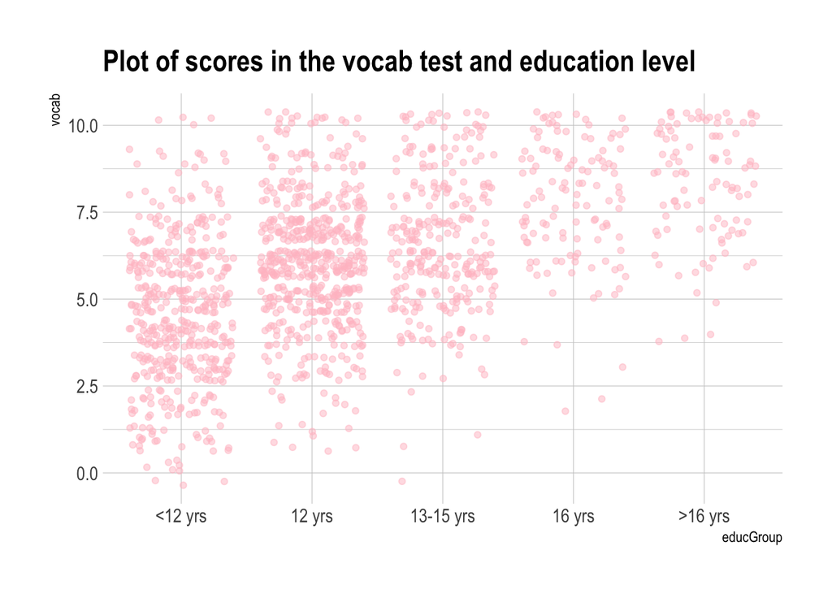

```r
df_new %>%
  ggplot(aes(x = educGroup, y = vocab)) +
  geom_point(color = "pink", position = "jitter", alpha = 0.5) +
  theme_ipsum() +
  ggtitle("Plot of scores in the vocab test and education level")
```

```r
summary(lm(vocab ~ educGroup, df_new))
```

```
##
## Call:
## lm(formula = vocab ~ educGroup, data = df_new)
##
## Residuals:
##     Min      1Q  Median      3Q     Max
## -6.5652 -1.3030 -0.0262  1.4348  5.4722
##
## Coefficients:
##                    Estimate Std. Error t value Pr(>|t|)
## (Intercept)         4.52784    0.09047   50.05   <2e-16 ***
## educGroup12 yrs     1.49838    0.12275   12.21   <2e-16 ***
## educGroup13-15 yrs  2.03738    0.14663   13.89   <2e-16 ***
## educGroup16 yrs     3.23687    0.19766   16.38   <2e-16 ***
## educGroup>16 yrs    3.77519    0.21285   17.74   <2e-16 ***
## ---
## Signif. codes:  0 '***' 0.001 '**' 0.01 '*' 0.05 '.' 0.1 ' ' 1
##
## Residual standard error: 1.917 on 1472 degrees of freedom
## Multiple R-squared:  0.2655, Adjusted R-squared:  0.2635
## F-statistic:   133 on 4 and 1472 DF,  p-value: < 2.2e-16
```

```r
m1 <- lm(vocab ~ educGroup, df_new)
```

*Answer:*

As shown in the summary of the linear model, all coefficients have p-values well below 0.001, indicating that a person’s score on the vocabulary test is significantly impacted by their education level. Furthermore, the model suggests that higher education levels are associated with higher vocabulary test scores.

The \( R^2 \) value of 0.2655 indicates that about 26.6% of the variance in vocabulary scores is explained by education group. Although education group is a significant predictor, the relatively low \( R^2 \) value suggests that other factors may also play an important role in predicting vocabulary scores.

4. Whether a person is the native of an English-speaking country(‘nativeBorn’) could potentially have an impact on the size of their vocabulary. Visualize the relationship and add the predictor to the model. Briefly explain the results.

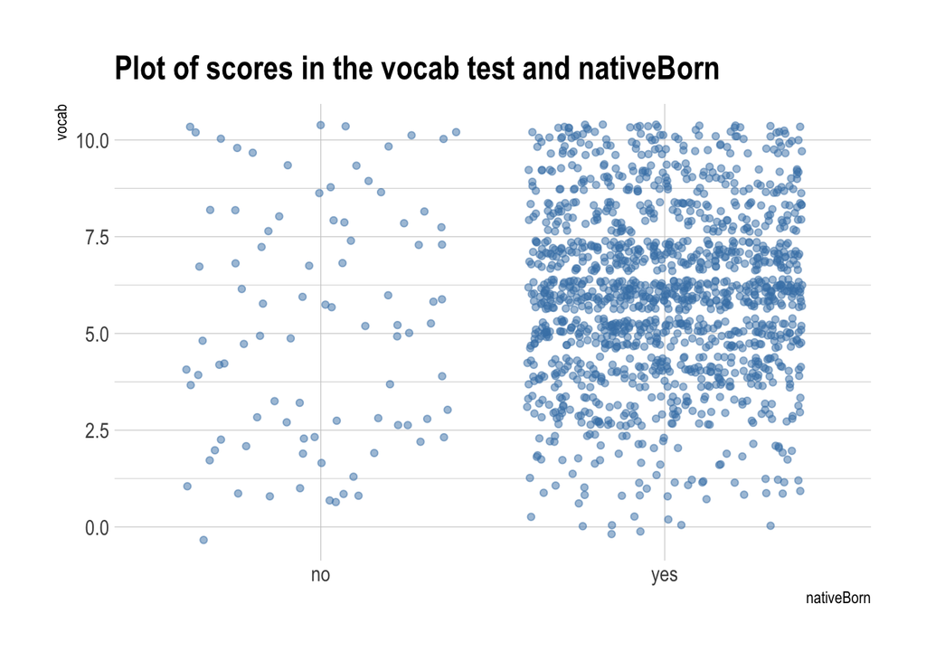

```r
# visualize the relationship
df_new %>%
  ggplot(aes(x = nativeBorn, y = vocab)) +
  geom_point(color = "steelblue", position = "jitter", alpha = 0.5) +
  theme_ipsum() +
  ggtitle("Plot of scores in the vocab test and nativeBorn")
```

```r
# model with native born
summary(lm(vocab ~ educGroup + nativeBorn, df_new))
```

```
##
## Call:
## lm(formula = vocab ~ educGroup + nativeBorn, data = df_new)
##
## Residuals:
##     Min      1Q  Median      3Q     Max
## -6.6117 -1.3036 -0.0587  1.3883  6.1768
##
## Coefficients:
##                    Estimate Std. Error t value Pr(>|t|)
## (Intercept)          3.8232     0.2151  17.771  < 2e-16 ***
## educGroup12 yrs      1.4804     0.1224  12.100  < 2e-16 ***
## educGroup13-15 yrs   2.0334     0.1460  13.924  < 2e-16 ***
## educGroup16 yrs      3.2689     0.1971  16.589  < 2e-16 ***
## educGroup>16 yrs     3.7705     0.2120  17.786  < 2e-16 ***
## nativeBornyes        0.7551     0.2094   3.607  0.00032 ***
## ---
## Signif. codes:  0 '***' 0.001 '**' 0.01 '*' 0.05 '.' 0.1 ' ' 1
##
## Residual standard error: 1.909 on 1471 degrees of freedom
## Multiple R-squared:  0.2719, Adjusted R-squared:  0.2695
## F-statistic: 109.9 on 5 and 1471 DF,  p-value: < 2.2e-16
```

```r
m2 <- lm(vocab ~ educGroup + nativeBorn, df_new)
```

*Answer:*

NativeBorn is a significant predictor indicating that being a native of an english-speaking country significantly impacts vocab-test scores.

An important point to consider is that, as seen in the scatterplot, the dataset contains a lower number of non-native English speakers. This smaller sample size may not fully capture the diversity of abilities within the non-native group, potentially leading to skewed results.

5.

Does a person’s level of education depend on whether they are a native of the country? Visualize the relationship. Do you think it makes sense to add the relationship as an interaction term? Try creating the model and briefly explain the result

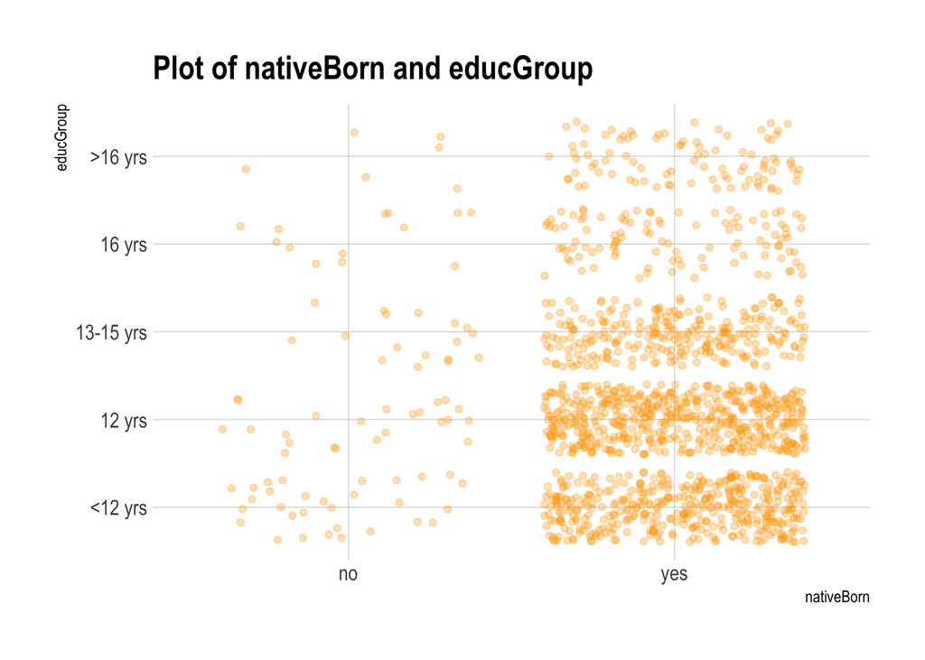

```r
# visualizing the relationsship
df_new %>%
  ggplot(aes(x = nativeBorn, y = educGroup)) +
  geom_point(color = "orange", position = "jitter", alpha = 0.3) +
  theme_ipsum() +
  ggtitle("Plot of nativeBorn and educGroup")
```

```r
# creating the model
summary(lm(vocab ~ educGroup*nativeBorn, df_new))
```

```
##
## Call:
## lm(formula = vocab ~ educGroup * nativeBorn, data = df_new)
##
## Residuals:
##     Min      1Q  Median      3Q     Max
## -6.5869 -1.3226 -0.0802  1.4131  6.2667
##
## Coefficients:
##                                  Estimate Std. Error t value Pr(>|t|)
## (Intercept)                        3.7333     0.3487  10.707  < 2e-16 ***
## educGroup12 yrs                    1.0928     0.5293   2.064   0.0391 *
## educGroup13-15 yrs                 2.5020     0.5798   4.315 1.70e-05 ***
## educGroup16 yrs                    3.7282     0.6342   5.879 5.10e-09 ***
## educGroup>16 yrs                   4.2667     0.8541   4.995 6.57e-07 ***
## nativeBornyes                      0.8514     0.3610   2.359   0.0185 *
## educGroup12 yrs:nativeBornyes      0.4028     0.5441   0.740   0.4593
## educGroup13-15 yrs:nativeBornyes  -0.4998     0.5991  -0.834   0.4043
## educGroup16 yrs:nativeBornyes     -0.5110     0.6673  -0.766   0.4439
## educGroup>16 yrs:nativeBornyes    -0.5288     0.8817  -0.600   0.5488
## ---
## Signif. codes:  0 '***' 0.001 '**' 0.01 '*' 0.05 '.' 0.1 ' ' 1
##
## Residual standard error: 1.91 on 1467 degrees of freedom
## Multiple R-squared:  0.2735, Adjusted R-squared:  0.269
## F-statistic: 61.36 on 9 and 1467 DF,  p-value: < 2.2e-16
```

```r
m3 <- lm(vocab ~ educGroup*nativeBorn, df_new)
```

Which model performs best?

```r
anova(m1,m2,m3)
```

```
## Analysis of Variance Table
##
## Model 1: vocab ~ educGroup
## Model 2: vocab ~ educGroup + nativeBorn
## Model 3: vocab ~ educGroup * nativeBorn
##   Res.Df    RSS Df Sum of Sq       F    Pr(>F)
## 1   1472 5409.7
## 2   1471 5362.3  1    47.426 13.0024 0.0003215 ***
## 3   1467 5350.9  4    11.385  0.7803 0.5379290
## ---
## Signif. codes:  0 '***' 0.001 '**' 0.01 '*' 0.05 '.' 0.1 ' ' 1
```

*Answer:*

Model 2 has a significant F-test, p=0.0003, indicating that adding the predictor nativeBorn significantly improves the model. In contrast, Model 3 does not have a significant F-test, meaning that including the interaction between educGroup and nativeBorn does not significantly improve model fit. Therefore, Model 2 is the best model.